# Aventura Estatística na Biblioteca Omar Catunda

Sylvia Bastian do Lago / Pedro Paulo Gomes

2026-09-30

## 1. Introdução e Plano de Amostragem

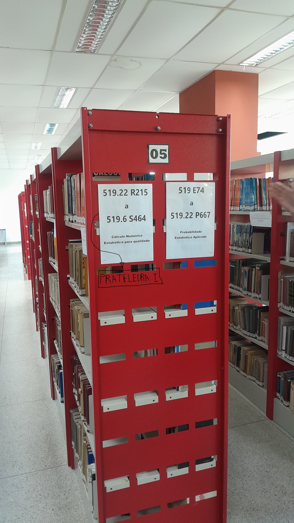

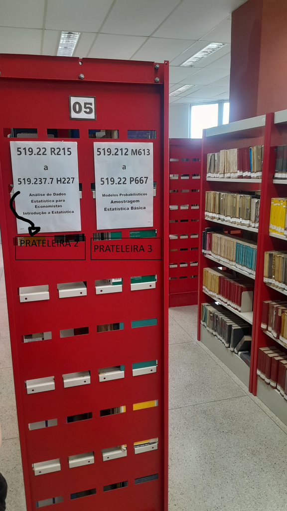

O tamanho amostral exato foi de 8 unidades experimentais (livros) por tratamento, totalizando 24 observações.

O experimento assume o Modelo de Efeitos Fixos do Delineamento Inteiramente Casualizado, expresso algebricamente como:
$$Y_{ij} = \mu + \tau_i + \varepsilon_{ij}, \quad i
= 1, 2, 3; \quad j = 1, \dots, 8$$
Onde:

$Y_{ij}$: Variável resposta (número de páginas do $j$-ésimo livro no $i$-ésimo tratamento).

$\mu$: Média global verdadeira do experimento.

$\tau_i$: Efeito fixo da $i$-ésima prateleira, sujeito à restrição $\sum_{i=1}^{3} \tau_i = 0$.

$\varepsilon_{ij}$: Erro aleatório, assumido independente e identicamente distribuído, $\varepsilon_{ij} \sim \mathcal{N}(0, \sigma^2)$.

```r
# Cada grupo usa uma semente diferente.
set.seed(200626)
prateleiras <- c("Prateleira 1", "Prateleira 2", "Prateleira 3")
n_por_prateleira <- 8

plano <- expand.grid(
  prateleira = prateleiras,
  livro_id = 1:n_por_prateleira
) |>
  mutate(
    ordem_medicao = sample(1:n()),
    posicao = sample(1:14, n(), replace = TRUE),
    aluno = rep(c("S", "P"), length.out = n()),
  ) |>
  arrange(ordem_medicao)

kable(plano, caption = "Plano de amostragem e ordem de medição 📋")
```

Plano de amostragem e ordem de medição 📋

| prateleira | livro_id | ordem_medicao | posicao | aluno |
| --- | --- | --- | --- | --- |
| Prateleira 3 | 4 | 1 | 9 | P |
| Prateleira 3 | 5 | 2 | 5 | S |
| Prateleira 1 | 8 | 3 | 8 | P |
| Prateleira 2 | 8 | 4 | 11 | S |
| Prateleira 1 | 7 | 5 | 5 | S |
| Prateleira 3 | 1 | 6 | 6 | S |
| Prateleira 3 | 6 | 7 | 4 | P |
| Prateleira 1 | 1 | 8 | 14 | S |
| Prateleira 1 | 4 | 9 | 7 | P |
| Prateleira 1 | 3 | 10 | 1 | S |
| Prateleira 2 | 7 | 11 | 2 | P |
| Prateleira 1 | 6 | 12 | 2 | P |
| Prateleira 2 | 5 | 13 | 1 | P |
| Prateleira 2 | 4 | 14 | 10 | S |
| Prateleira 2 | 3 | 15 | 3 | P |
| Prateleira 3 | 3 | 16 | 2 | S |
| Prateleira 3 | 8 | 17 | 14 | P |
| Prateleira 1 | 5 | 18 | 5 | S |
| Prateleira 2 | 1 | 19 | 5 | P |
| Prateleira 2 | 6 | 20 | 4 | S |
| Prateleira 3 | 2 | 21 | 8 | P |
| Prateleira 2 | 2 | 22 | 2 | S |
| Prateleira 3 | 7 | 23 | 8 | S |
| Prateleira 1 | 2 | 24 | 4 | P |

## 2. Análise Descritiva e Gráfica

```r
dados <- tibble(
  prateleira = c(
    rep("Prateleira 1", 8),
    rep("Prateleira 2", 8),
    rep("Prateleira 3", 8)
  ),
  livro_id = rep(1:8, 3),
  paginas = c(
    430, 369, 113, 430, 428, 711, 427, 430,
    321, 379, 379, 223, 372, 379, 379, 489,
    426, 426, 106, 426, 426, 426, 417, 345
  )
)

dados |>
  group_by(prateleira) |>
  summarise(
    n = n(),
    media = mean(paginas, na.rm = TRUE),
    desvio = sd(paginas, na.rm = TRUE),
    mediana = median(paginas, na.rm = TRUE),
    minimo = min(paginas, na.rm = TRUE),
    maximo = max(paginas, na.rm = TRUE)
  ) |>
  kable(caption = "Estatísticas descritivas por prateleira")
```

Estatísticas descritivas por prateleira

| prateleira | n | media | desvio | mediana | minimo | maximo |
| --- | --- | --- | --- | --- | --- | --- |
| Prateleira 1 | 8 | 417.250 | 161.19354 | 429 | 113 | 711 |
| Prateleira 2 | 8 | 365.125 | 73.97768 | 379 | 223 | 489 |
| Prateleira 3 | 8 | 374.750 | 112.14117 | 426 | 106 | 426 |

A **Prateleira 1** apresentou a maior média de páginas ($\approx 417,25$), mas também a maior dispersão (desvio padrão de $\approx 161,19$), variando de um livro muito fino (113 páginas) até um bem extenso (711 páginas). A **Prateleira 2** teve média de $\approx 365,13$ páginas e foi a mais homogênea (desvio padrão menor, $\approx 73,98$). A **Prateleira 3** ficou com média de $\approx 374,75$ páginas, exibindo também uma boa variação (com mínimo de 106 e máximo de 426).

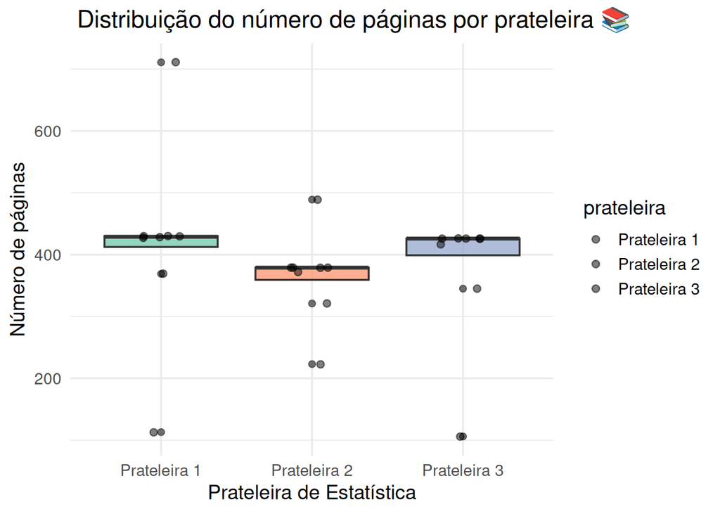

```r
ggplot(dados, aes(x = prateleira, y = paginas, fill = prateleira)) +
  geom_boxplot(alpha = 0.7, show.legend = FALSE) +
  geom_jitter(width = 0.15, size = 2, alpha = 0.5) +
  labs(
    title = " Distribuição do número de páginas por prateleira 📚" ,
    x = "Prateleira de Estatística",
    y = "Número de páginas"
  ) +
  theme_minimal(base_size = 14) +
  scale_fill_brewer(palette = "Set2")
```

**No Gráfico (Boxplot):** É possível notar visualmente que as medianas das três prateleiras estão em patamares relativamente parecidos, mas há alguns pontos isolados (outliers) representando livros com números de páginas bem destoantes do restante daquela prateleira específica.

## 3. Análise de Variância (ANOVA) e Diagnóstico

```r
modelo <- aov(paginas ~ prateleira, data = dados)
anova_tab <- summary(modelo)
print(anova_tab)
```

```
##             Df Sum Sq Mean Sq F value Pr(>F)
## prateleira   2  12309    6155   0.419  0.663
## Residuals   21 308222   14677
```

Como $p > 0.05$, não rejeitamos a hipótese nula ($H_0$). Isso significa que não há evidência estatística significativa de que a média do número de páginas seja diferente entre as três prateleiras avaliadas. Os livros de Estatística parecem ter distribuições de tamanho semelhantes independentemente de qual dessas três prateleiras foram retirados.

O valor de $\text{QM}_{Res} = 14677$ expõe uma alta variabilidade dentro das próprias prateleiras (livros variando de 106 a 711 páginas no mesmo nível de tratamento). Essa variância residual inflada reduz drasticamente o poder estatístico do teste ($1-\beta$), ofuscando o efeito do tratamento ($\text{QM}_{Trat} = 6155$). A estatística calculada $F_{calc} = 0,419$ resulta em um valor-p de $0,663$. Como o p-valor $> \alpha$ (0,05), não rejeitamos a hipótese nula global de igualdade das médias, controlando a taxa de erro tipo I. O teste de Tukey não deve ser aplicado.

```r
shapiro.test(residuals(modelo))
```

```
##
##  Shapiro-Wilk normality test
##
## data:  residuals(modelo)
## W = 0.81023, p-value = 0.0004351
```

O valor de $p$ foi $0,0004351$ (menor que $0,05$). Isso indica que a normalidade dos resíduos foi violada. Essa violação aconteceu justamente por conta dos valores extremos (outliers) observados na coleta (como os livros muito longos na Prateleira 1 ou os muito curtos).

Assim, o modelo original foi invalidado e duas abordagens corretivas foram aplicadas: Transformação de Box-Cox e o Teste Não-Paramétrico de Kruskal-Wallis.

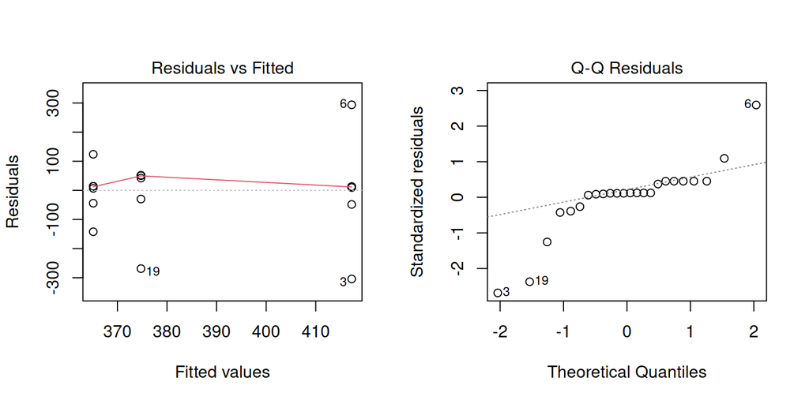

```r
par(mfrow=c(1,2))
plot(modelo, which=1) # Resíduos vs Ajustados
plot(modelo, which=2) # Normal Q-Q Plot
```

```r
kruskal_teste <- kruskal.test(paginas ~ prateleira, data = dados)
print(kruskal_teste)
```

```
##
##  Kruskal-Wallis rank sum test
##
## data:  paginas by prateleira
## Kruskal-Wallis chi-squared = 4.3087, df = 2, p-value = 0.116
```

```r
bc <- boxcox(modelo, lambda = seq(-2, 2, 0.1), plotit = FALSE)
opt_lambda <- bc$x[which.max(bc$y)]

dados <- dados %>%
  mutate(
    paginas_bc = ifelse(
      opt_lambda == 0,
      log(paginas),
      (paginas^opt_lambda - 1) / opt_lambda
    )
  )

modelo_bc <- aov(paginas_bc ~ prateleira, data = dados)
summary(modelo_bc)
```

```
##             Df    Sum Sq   Mean Sq F value Pr(>F)
## prateleira   2 3.720e-24 1.860e-24   0.993  0.387
## Residuals   21 3.934e-23 1.873e-24
```

```r
shapiro.test(residuals(modelo_bc))
```

```
##
##  Shapiro-Wilk normality test
##
## data:  residuals(modelo_bc)
## W = 0.41463, p-value = 9.209e-09
```

A aplicação da transformação de Box-Cox não foi bem-sucedida em normalizar os resíduos do modelo ($W = 0,41463$, $p = 9,209 \times 10^{-9}$). Esse comportamento decorre da própria natureza discreta e agrupada da variável número de páginas, que apresenta valores repetidos (empates na contagem padrão das editoras) e saltos causados por valores extremos (outliers). Diante das premissas paramétricas falhas mesmo após transformações, a inferência final se dá pelo teste não-paramétrico de Kruskal-Wallis, que não exige normalidade e confirma a ausência de diferenças estatísticas significativas entre as prateleiras ($p > 0,05$).

```r
dados$prateleira <- as.factor(dados$prateleira)
leveneTest(paginas ~ prateleira, data = dados)
```

```
## Levene's Test for Homogeneity of Variance (center = median)
##       Df F value Pr(>F)
## group  2  0.3283 0.7238
##       21
```

O valor de $p$ foi $0,7238$ (maior que $0,05$). Assim, a premissa de homoscedasticidade (igualdade de variâncias entre os grupos) foi atendida.

## 4. Conclusão

Com base na análise de variância (ANOVA) de um fator, com um p-valor de $0,663$, não rejeitamos a hipótese nula inicial. A validade desse p-valor original foi questionada, pois embora o teste de Levene tenha confirmado a homocedasticidade, o teste de Shapiro-Wilk apontou violação severa da normalidade dos resíduos (influenciada por livros extremos em espessura).

Conclui-se que não há evidência estatística de que a média de páginas divirja entre as prateleiras. A altíssima variação residual reflete a natureza heterogênea do acervo de exatas nas próprias divisões. Como limitações, enfrentamos o pequeno tamanho amostral (8 unidades por prateleira) e sugerimos para trabalhos futuros a inclusão da espessura física e o ano de publicação como variáveis auxiliares (covariáveis).

## 5. Extras

**1. Livro mais antigo** O livro mais antigo achado na biblioteca, dentre os nossos tratamentos foi: *CROXTON, Frederick E.; COWDEN, Dudley J. Estatística geral e aplicada. Rio de Janeiro: Instituto Brasileiro de Geografia e Estatística, 1952*.

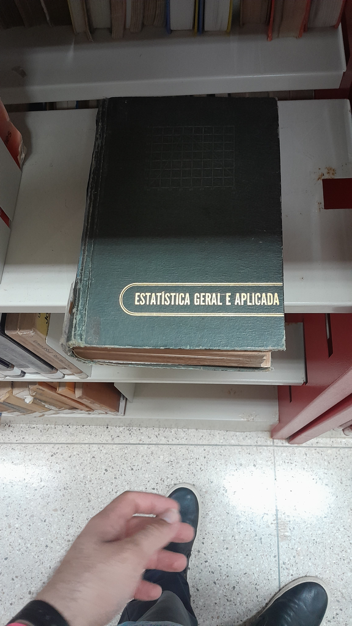

**2. Extremos de espessura** Já o livro mais extremo em espessura foi: *CROXTON, Frederick E.; COWDEN, Dudley J. Estatística geral e aplicada. Rio de Janeiro: Instituto Brasileiro de Geografia e Estatística, 1952*. Este livro está na prateleira 519.22 e é identificado como C953.

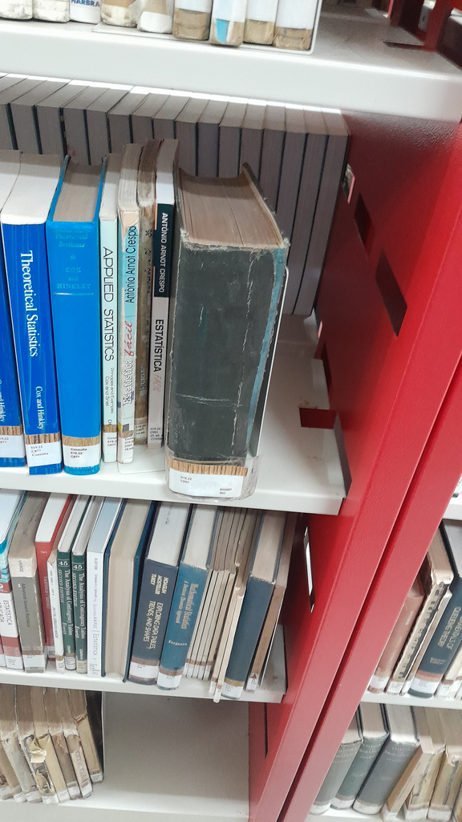

Em contraponto, o livro mais fino que achamos no nosso tratamento é: *NETER, John; KUTNER, Michael H.; NACHTSHEIM, Christopher J.; WASSERMAN, William. Student solutions manual for use with Applied linear regression models, third edition and Applied linear statistical models, fourth edition. Chicago: Irwin, 1996*.

[figure not shown]

**3. Sugestões de Replicação (Meta-experimento)** Caso o experimento fosse replicado, algumas melhorias metodológicas seriam implementadas para elevar a precisão e a confiabilidade dos dados. Primeiramente, adotar-se-ia uma análise prévia do acervo — utilizando o sistema Pergamum ou uma verificação presencial — para mapear com mais critério as estantes. Além disso, seria recomendável ampliar o número de prateleiras analisadas e aumentar o tamanho da amostra de livros. Do ponto de vista da execução, é fundamental estabelecer um protocolo rígido de mensuração, padronizando a contagem de páginas (definindo o tratamento de páginas não numeradas e de volumes defeituosos) e incorporando, opcionalmente, a medição da espessura física dos livros como variável complementar.

## 6. Meta-Análise dos Dados da Turma

Para verificar se o efeito da prateleira no número de páginas se mantém consistente entre os diferentes grupos de recolha da turma, procedeu-se a uma meta-análise dos resultados de quatro grupos (G1, G2, G3 e G4).

```r
# Carregar as bibliotecas
library(readxl)
library(metafor)

# Ler os dados gerais da turma
todos <- read_xlsx('dados_prateleiras.xlsx')

g1 <- filter(todos, grupo == 'G1') # Grupo 1: Tais e Rodrigo
g2 <- filter(todos, grupo == 'G2') # Grupo 2: Sylvia e Pedro
g3 <- filter(todos, grupo == 'G3') # Grupo 3: Bia e Caio
g4 <- filter(todos, grupo == 'G4') # Grupo 4: Luca e Vitor

resumo_list <- list()

for (grupo_name_str in c('g1', 'g2', 'g3', 'g4')) {
  grupo_data <- get(grupo_name_str)

  # ANOVA
  modelo <- aov(paginas ~ prateleira, data = grupo_data)
  tabela_summary <- summary(modelo)[[1]]

  # SS, p_valor e eta2
  ss_entre <- tabela_summary[1, "Sum Sq"]
  ss_total <- sum(tabela_summary[, "Sum Sq"])
  p_valor <- tabela_summary[1, 'Pr(>F)']
  eta2 <- ss_entre / ss_total

  n <- nrow(grupo_data)

  # Tamanho do efeito (d de Cohen) e Variância de d
  d <- 2 * sqrt(eta2 / (1 - eta2))
  var_d <- (4 / n) * (1 + d^2 / 8)

  # Tabela com as estatísticas
  current_group_res <- tibble(
    grupo = grupo_name_str,
    n = n,
    eta2 = eta2,
    p = p_valor,
    d = d,
    var_d = var_d
  )

  # Adiciona à lista
  resumo_list[[grupo_name_str]] <- current_group_res
}

# Junta tudo e apresenta a tabela de forma elegante
resumo <- bind_rows(resumo_list)
kable(resumo, digits = 4, caption = "Resumo Estatístico por Grupo (Tamanho de Efeito e Variância)")
```

Resumo Estatístico por Grupo (Tamanho de Efeito e Variância)

| grupo | n | eta2 | p | d | var_d |
| --- | --- | --- | --- | --- | --- |
| g1 | 24 | 0.1208 | 0.2588 | 0.7413 | 0.1781 |
| g2 | 24 | 0.0384 | 0.6629 | 0.3997 | 0.1700 |
| g3 | 24 | 0.2097 | 0.0845 | 1.0301 | 0.1888 |
| g4 | 24 | 0.6795 | 0.0000 | 2.9122 | 0.3434 |

A partir dos tamanhos de efeito ($d$ de Cohen) obtidos em cada amostra independente, ajustamos um modelo de efeitos aleatórios para estimar o efeito global e avaliar a heterogeneidade entre os grupos.

```r
# Ajustar o modelo meta-analítico (REML)
meta <- rma(yi = d, vi = var_d, data = resumo, method = 'REML')

# Tabela de resultados do modelo
meta
```

```
##
## Random-Effects Model (k = 4; tau^2 estimator: REML)
##
## tau^2 (estimated amount of total heterogeneity): 0.8904 (SE = 0.9031)
## tau (square root of estimated tau^2 value):      0.9436
## I^2 (total heterogeneity / total variability):   81.14%
## H^2 (total variability / sampling variability):  5.30
##
## Test for Heterogeneity:
## Q(df = 3) = 13.1220, p-val = 0.0044
##
## Model Results:
##
## estimate      se    zval    pval   ci.lb   ci.ub
##   1.2128  0.5259  2.3063  0.0211  0.1821  2.2435  *
##
## ---
## Signif. codes:  0 '***' 0.001 '**' 0.01 '*' 0.05 '.' 0.1 ' ' 1
```

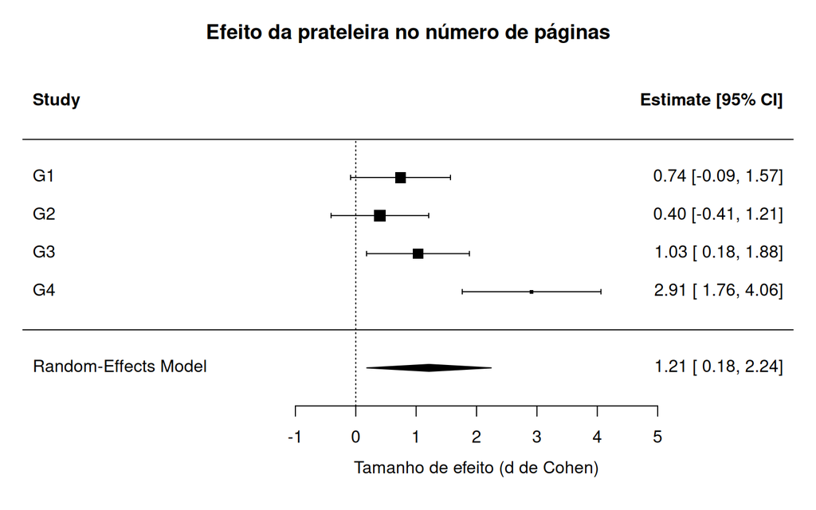

```r
# Gráfico de Floresta (Forest Plot)
forest(meta,
       slab = toupper(resumo$grupo),
       xlab = "Tamanho de efeito (d de Cohen)",
       main = "Efeito da prateleira no número de páginas")
```

### Análise dos Efeitos Individuais

Ao observar os resultados isolados, vemos uma grande discrepância entre as coletas da turma. O nosso grupo (G2) e o G1 não encontraram diferenças significativas entre as prateleiras ($p = 0,663$ e $p = 0,259$, respectivamente), apresentando tamanhos de efeito de $d = 0,400$ e $d = 0,741$. O G3 encontrou um efeito forte ($d = 1,03$), mas ainda marginalmente não significativo a 5% ($p = 0,0845$). Em contrapartida, o G4 detectou um efeito alto e significativo ($d = 2,91$; $p = 0,00000647$).

### Síntese Meta-Analítica e Heterogeneidade

Ao combinar as quatro amostras através de um Modelo de Efeitos Aleatórios (REML), o tamanho de efeito global estimado foi de $d = 1,21$ (IC 95%: $0,18$ a $2,24$), indicando que, na média da turma, há um efeito estatisticamente significativo da prateleira sobre o número de páginas ($p = 0,0211$). O gráfico de floresta (*Forest Plot*) ilustra esse efeito global distanciado do zero, mas deixa claro que o resultado combinado foi fortemente puxado pelo viés do G4.

O mais importante desta meta-análise, no entanto, é a alta heterogeneidade entre as coletas. O teste Q de Cochran rejeitou a hipótese de homogeneidade dos efeitos ($Q = 13.12$; $p = 0.0044$). Além disso, a estatística $I^2$ indicou que $81.14\%$ da variabilidade total observada se deve à verdadeira heterogeneidade entre os grupos, e não ao mero erro amostral. A variância real estimada entre os grupos foi de $\tau^2 = 0.8904$.

### Conclusão Final (Meta-experimento)

A alta heterogeneidade ($I^2 = 81.14\%$) indica que os grupos não estimaram o mesmo efeito populacional. Como todos os nós fomos à mesma biblioteca e medimos as mesmas estantes, essa divergência evidencia falhas e possíveis vieses de seleção durante a execução física do Delineamento Inteiramente Casualizado (DIC).

A falta de um protocolo rigoroso para a escolha exata da posição do livro permitiu que a amostragem fosse subjetiva. Isso consolida a nossa conclusão inicial: em experimentos práticos, a aleatorização precisa estar bem fundamentada.